#### 5. Compare and contrast geom_violin() with a facetted geom_histogram(), or a coloured geom_freqpoly(). What are the pros and cons of each method?

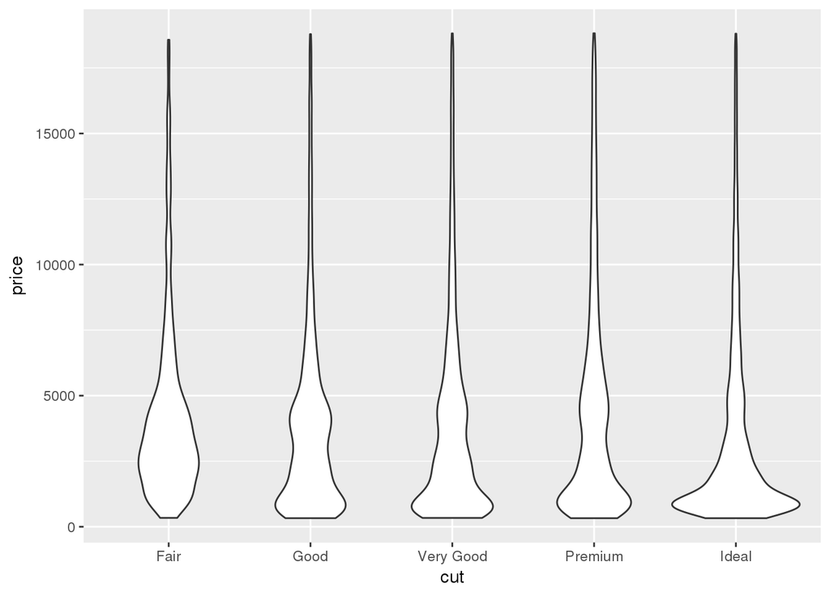

```r
#geom_violin
ggplot(data = diamonds)+
  geom_violin(mapping= aes(x = cut, y = price))
```

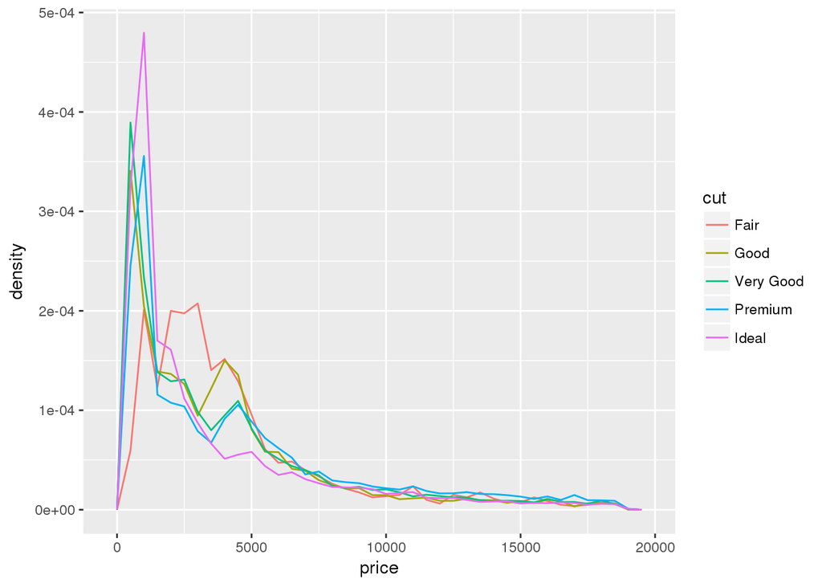

```r
#geom_freqpoly
ggplot(data = diamonds, aes(x = price, y = ..density..))+
  geom_freqpoly(mapping = aes(color = cut), binwidth = 500)
```

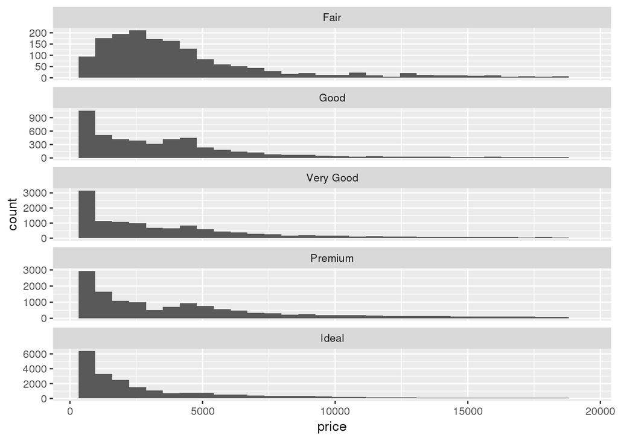

```r
#facetted geom_histogram
ggplot(data = diamonds, mapping = aes(x = price)) +
  geom_histogram() +
  facet_wrap(~ cut, ncol = 1, scales = "free_y")
```

In the geom_freqpoly graph, it is easy to understand where the major peaks are, but harder to generalize different trends. The violin and histogram plots have similar strengths and weaknesses. In both, we can understand differences in the distributions; however, we can’t understand where majors peaks are.

#### 6. If you have a small dataset, it’s sometimes useful to use geom_jitter() to see the relationship between a continuous and categorical variable. The ggbeeswarm package provides a number of methods similar to geom_jitter(). List them and briefly describe what each one does.

There are two methods similar to geom_jitter in ggbeeswarm:  
* geom_quasirandom- reduces overplotting by offsetting points within categories through special jitter methods  
* geom_beeswarm- also offsets points within categories, similar to violin

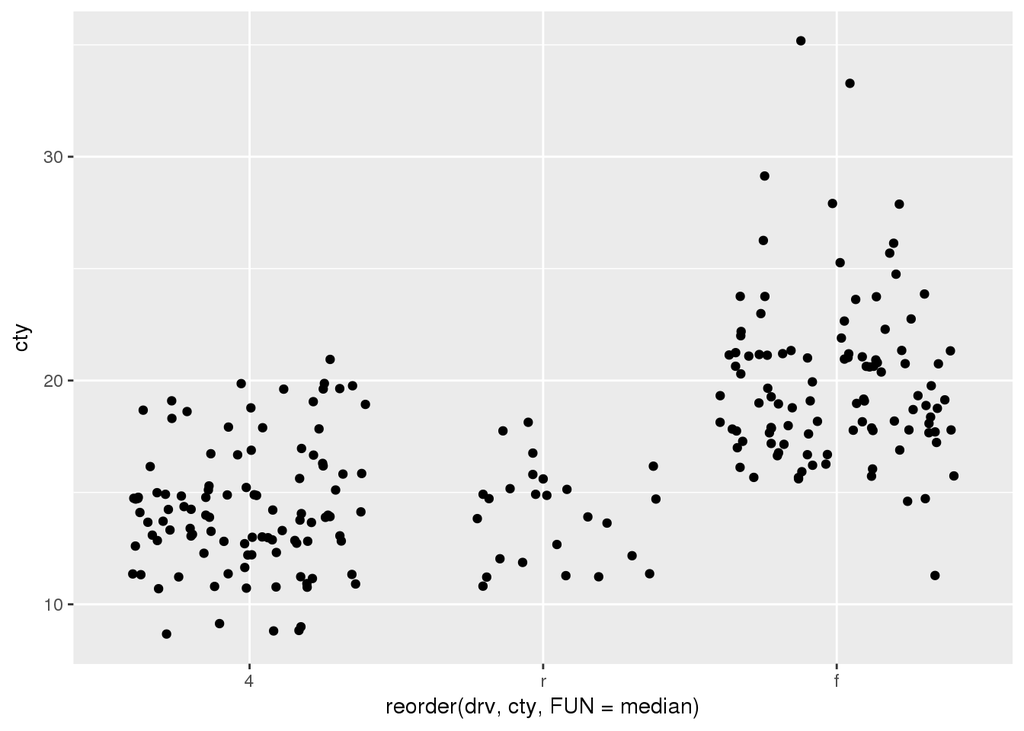

```r
#install.packages('ggbeeswarm')

ggplot(data = mpg) +
  geom_jitter(mapping = aes(x = reorder(drv, cty, FUN = median),
                            y = cty))
```

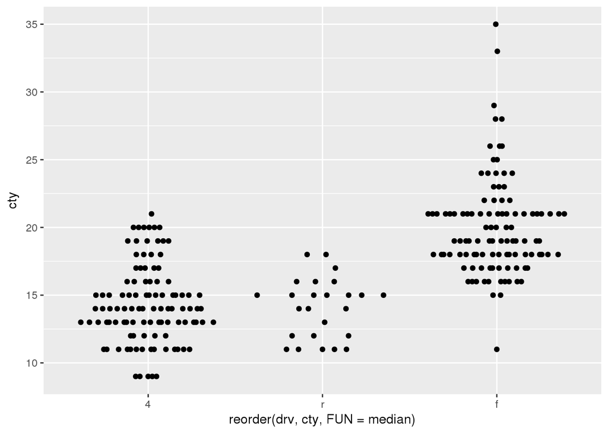

```r
ggplot(data = mpg) +
  geom_quasirandom(mapping = aes(x = reorder(drv, cty, FUN = median),
                                 y = cty))
```

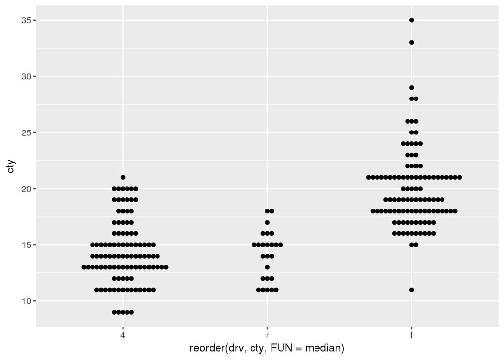

```r
ggplot(data = mpg) +
  geom_beeswarm(mapping = aes(x = reorder(drv, cty, FUN = median),
                                 y = cty))
```

### 7.5.2.1

#### 1. How could you rescale the count dataset above to more clearly show the distribution of cut within colour, or colour within cut?

- Cut within colour:

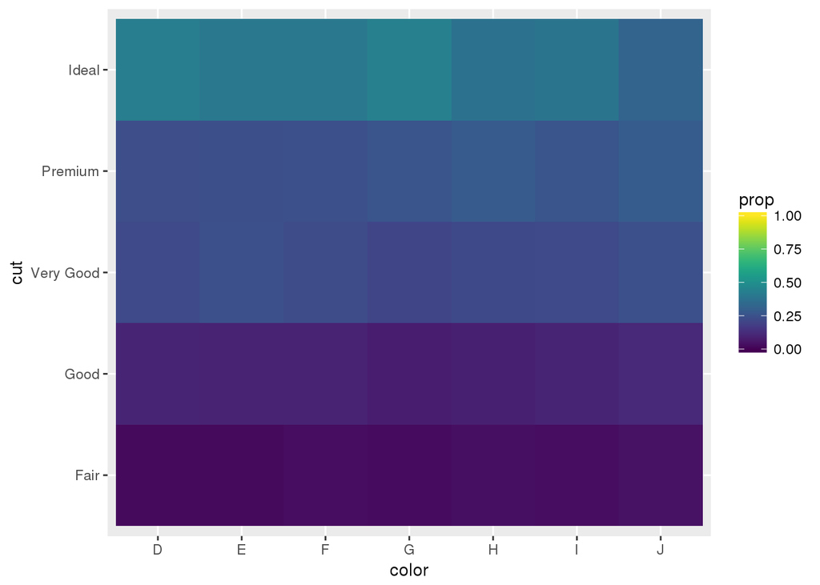

```r
diamonds %>%
  count(color, cut) %>%
  group_by(color) %>%
  mutate(prop = n / sum(n)) %>%
  ggplot(mapping = aes(x = color, y = cut)) +
  geom_tile(mapping = aes(fill = prop)) +
  scale_fill_viridis(limits = c(0, 1))
```

- Colour within cut:

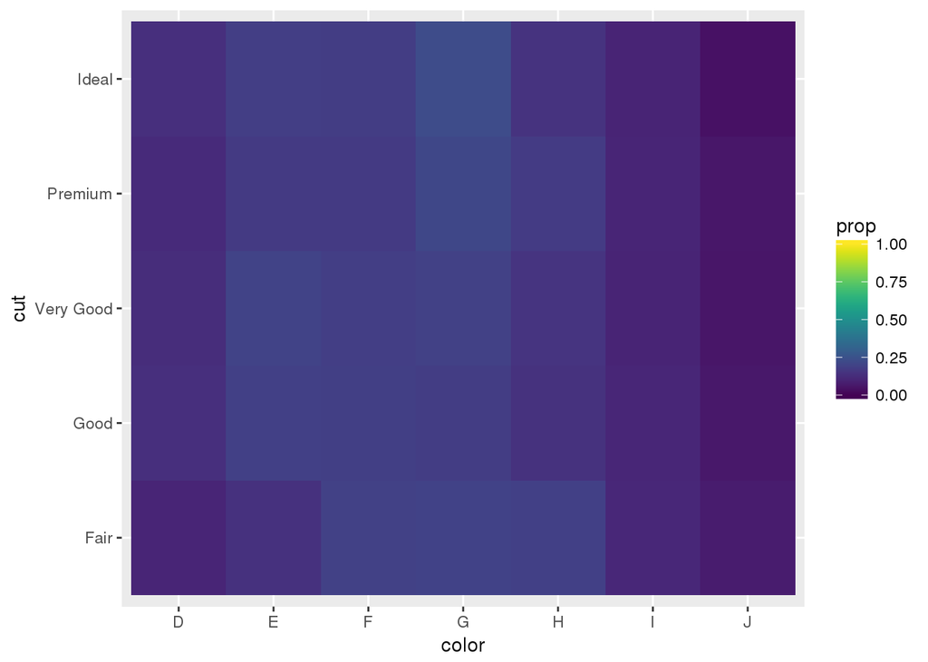

```r
diamonds %>%
  count(color, cut) %>%
  group_by(cut) %>%
  mutate(prop = n / sum(n)) %>%
  ggplot(mapping = aes(x = color, y = cut)) +
  geom_tile(mapping = aes(fill = prop)) +
  scale_fill_viridis(limits = c(0, 1), option = 'heat')
```

#### 2. Use geom_tile() together with dplyr to explore how average flight delays vary by destination and month of year. What makes the plot difficult to read? How could you improve it?

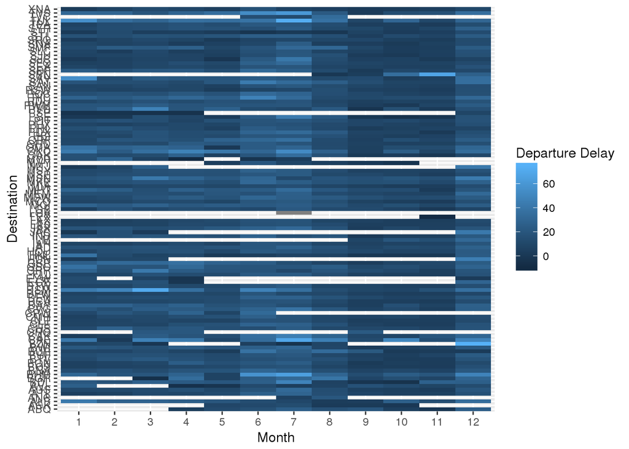

```r
flights %>%
  group_by(month, dest) %>%
  summarise(mean_del = mean(dep_delay, na.rm = TRUE)) %>%
  ggplot(aes(x = factor(month), y = dest, fill = mean_del)) +
  geom_tile() +
  labs(x = "Month", y = "Destination", fill = "Departure Delay")
```

#### 3. Why is it slightly better to use aes(x = color, y = cut) rather than aes(x = cut, y = color) in the example above?

It was done more for reasons of clarity. Since the cut variable has longer label names, it is easier to read when placed on the y-axis.

### 7.5.3.1

#### 1. Instead of summarising the conditional distribution with a boxplot, you could use a frequency polygon. What do you need to consider when using cut_width() vs cut_number()? How does that impact a visualisation of the 2d distribution of carat and price?

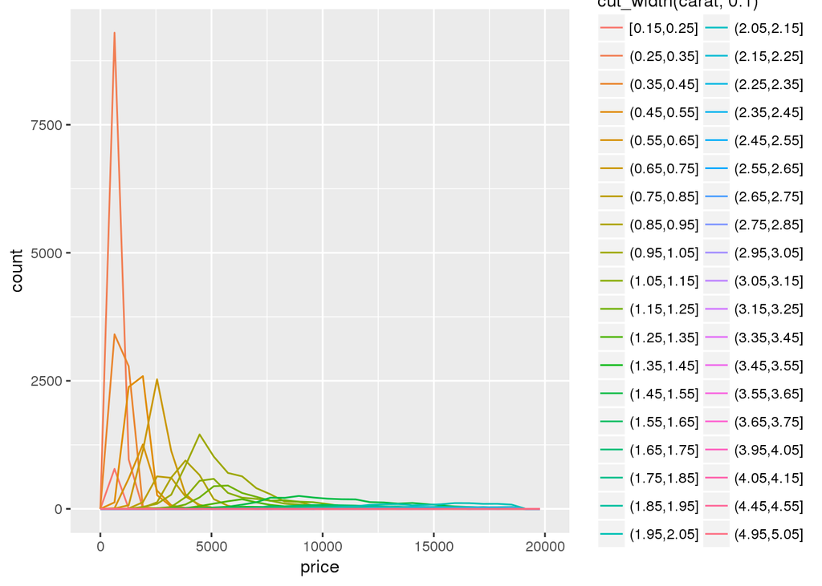

```r
ggplot(data = diamonds, mapping = aes(x = price,
                                      colour = cut_width(carat, 0.1))) +
  geom_freqpoly()
```

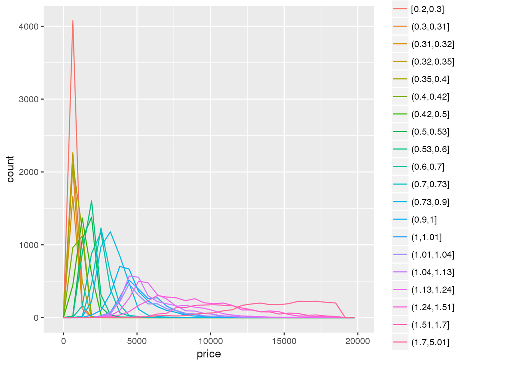

```r
ggplot(data = diamonds, mapping = aes(x = price,
                                      colour = cut_number(carat, 20))) +
  geom_freqpoly()
```

When specifiying cut width, you are specifying restricted intervals that may or may not have any items in them especially when they are right skewed. Since the carat distribution is right skewed, bins for higher values will not have as many diamonds in them.

The interval lengths when cut number is specified are different as there is a fixed number of diamonds allotted to each interval. Furthermore, the density and count plots will be the same when cut number is specified.

#### 2. Visualize the distribution of carat, partitioned by price.

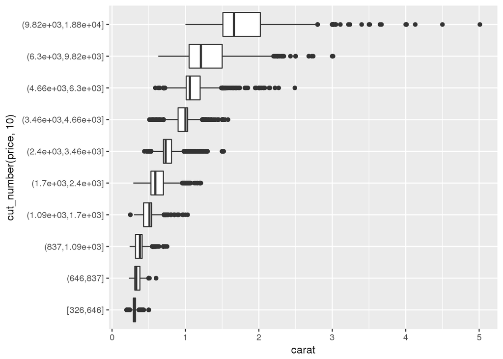

```r
ggplot(diamonds, aes(x = cut_number(price, 10), y = carat)) +
  geom_boxplot()+
  coord_flip()
```

#### 3. How does the price distribution of very large diamonds compare to small diamonds. Is it as you expect, or does it surprise you?

Very large diamonds (>3 carats) all cost more than approximately $6300. They are the most expensive diamonds. This does not surprise me. The distribution of diamond prices for larger diamonds are variable as well with things such cut and clarity playing a role in influencing price.

#### 4. Combine two of the techniques you’ve learned to visualise the combined distribution of cut, carat, and price.

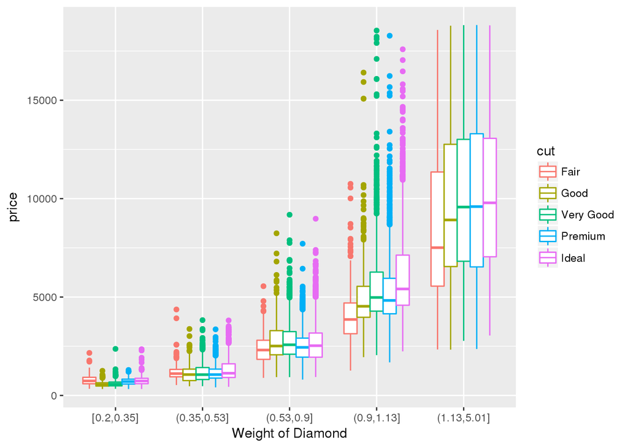

```r
ggplot(diamonds, aes(x = cut_number(carat, 5), y = price, color = cut)) +
  geom_boxplot() +
  xlab('Weight of Diamond')
```

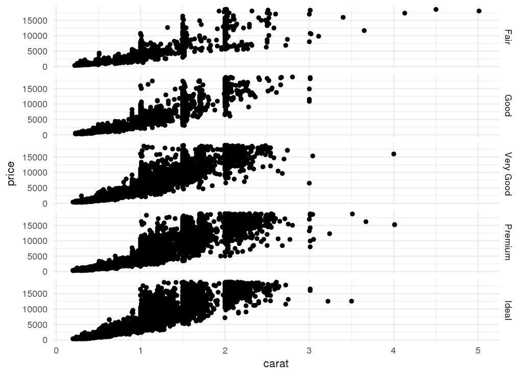

```r
ggplot(data = diamonds,
       mapping = aes(x = carat, y = price)) +
  geom_point()+
  facet_grid(cut~.)+
  theme_minimal()
```